# Sediment Source Modeling with Batista-Style

**AUTHOR**  
Rodrigo Kang

## Overview

This notebook accompanies the portfolio project **Sediment Source Modeling** in the **Climate and Environmental Systems** section of *Data Science Across Domains*.

The Python implementation is based on the sediment fingerprinting workflow of Batista, Laceby and Evrard (2022), who evaluate source apportionment methods using artificial mixtures with known source proportions. The notebook has two stages: a reproducible implementation of the workflow, followed by a short critical assessment of modelling assumptions and diagnostics.

## Imports and Configuration

Paths, output directories, and stochastic settings are centralised here. With the expected project layout, the notebook runs from the `python` directory, reads the project data from the sibling `data` directory, and stores all generated figures and summary tables in `python/1-batista`.

```python
from __future__ import annotations

import itertools
import zipfile
from pathlib import Path
from typing import Iterable

import matplotlib.pyplot as plt
import numpy as np
import pandas as pd
from scipy.optimize import minimize
from scipy.special import logsumexp
from scipy.stats import kruskal
from sklearn.discriminant_analysis import LinearDiscriminantAnalysis
from sklearn.metrics import confusion_matrix
from sklearn.model_selection import StratifiedKFold, cross_val_score
from sklearn.preprocessing import StandardScaler
```

```python
# Configuration

random_seed = 42

notebook_dir = Path.cwd()
project_root = notebook_dir.parent if notebook_dir.name == "python" else notebook_dir

data_dir = project_root / "data"

# Output directories
output_dir = project_root / "python" / "1-batista"
figures_dir = output_dir / "figures"
tables_dir = output_dir / "tables"

for directory in (
    output_dir,
    figures_dir,
    tables_dir,
):
    directory.mkdir(parents=True, exist_ok=True)

# Modeling parameters

bmm_iterations = 2500
bayesian_candidates = 25_000
posterior_draws = 2500

# Plot style

plt.rcParams.update({
    "figure.figsize": (8, 5),
    "axes.spines.top": False,
    "axes.spines.right": False,
    "axes.grid": True,
    "grid.alpha": 0.25,
    "font.size": 10,
})
```

## Data Loading

The project uses three input datasets:

- **`mixture_proportions.csv`**: known source proportions for the artificial mixtures.
- **`fingerprint_data.csv`**: geochemical and colour fingerprint measurements for both source samples and laboratory mixtures.
- **`selected_tracers.csv`**: tracer variables selected through the screening procedure used for the analysis.

The four source classes are **Subsurface**, **Decontaminated**, **Cropland**, and **Forest**. In the source data, cropland is identified as `source_PF`, which is renamed in this notebook for clarity and consistency.

```python
# Load datasets
proportions_raw = pd.read_csv(data_dir / "mixture_proportions.csv")
fingerprints = pd.read_csv(data_dir / "fingerprint_data.csv")
selected_tracers = pd.read_csv(data_dir / "selected_tracers.csv")["x"].tolist()

source_name_map = {
    "source_s": "Subsurface",
    "source_d": "Decontaminated",
    "source_pf": "Cropland",
    "source_f": "Forest",
}

source_order = list(source_name_map.values())

proportions = (
    proportions_raw
    .rename(columns={
        "sediment_sample": "sample",
        "source_S": "Subsurface",
        "source_D": "Decontaminated",
        "source_PF": "Cropland",
        "source_F": "Forest",
    })
)

missing_proportion_columns = [
    col for col in ["sample", *source_order]
    if col not in proportions.columns
]

if missing_proportion_columns:
    raise ValueError(
        f"Missing columns in mixture proportions table: {missing_proportion_columns}"
    )

proportions[source_order] = proportions[source_order].astype(float)

sources = fingerprints.query("type == 'source'").copy()
targets_lab = fingerprints.query("type == 'target'").copy()

sources["source_label"] = (
    sources["source"]
    .str.lower()
    .map(source_name_map)
)

if sources["source_label"].isna().any():
    unmapped_sources = sources.loc[
        sources["source_label"].isna(), "source"
    ].unique()

    raise ValueError(
        f"Unmapped source labels found in fingerprint data: {unmapped_sources}"
    )

print(f"Source samples: {sources.shape[0]}")
print(f"Laboratory mixtures: {targets_lab.shape[0]}")
print(f"Selected tracers: {selected_tracers}")
print(sources["source_label"].value_counts().reindex(source_order))
```

```
Source samples: 70
Laboratory mixtures: 79
Selected tracers: ['L', 'h', 'Si', 'Zn', 'Mn', 'K', 'Ti', 'y', 'C_star']
source_label
Subsurface         9
Decontaminated    13
Cropland          18
Forest            30
Name: count, dtype: int64
```

## Data Preparation

The fingerprint dataset contains both geochemical and colourimetric measurements for source samples and artificial laboratory mixtures. The analysis is restricted to the nine selected tracers used in the modelling workflow.

Before modelling, the selected tracers are log-transformed. This transformation improves the approximation to normality for strictly positive variables and is consistent with the assumptions of the statistical models used below, particularly the Bayesian mixing framework.

```python
if (sources[selected_tracers] <= 0).any().any():
    raise ValueError("All selected source tracers must be positive before log transformation.")

if (targets_lab[selected_tracers] <= 0).any().any():
    raise ValueError("All selected laboratory mixture tracers must be positive before log transformation.")

if len(proportions) != len(targets_lab):
    raise ValueError("The number of proportion rows and target mixtures does not match.")

missing_sources = [source for source in source_order if source not in proportions.columns]

if missing_sources:
    raise ValueError(f"Missing source columns in proportions table: {missing_sources}")

source_log_df = pd.concat([
    sources[["sample", "source", "source_label"]].reset_index(drop=True),
    np.log(sources[selected_tracers]).reset_index(drop=True),
], axis=1)

target_log_df = pd.concat([
    targets_lab[["sample"]].reset_index(drop=True),
    np.log(targets_lab[selected_tracers]).reset_index(drop=True),
], axis=1)

# The proportion table uses artificial-mixture IDs, while the fingerprint table
# stores laboratory mixture sample IDs. The rows follow the same experimental
# order, so the known proportions are aligned by row position.
truth = pd.concat([
    targets_lab[["sample"]].reset_index(drop=True),
    proportions[source_order].reset_index(drop=True),
], axis=1)

source_summary = (
    sources
    .groupby("source_label")[selected_tracers]
    .agg(["mean", "std"])
    .reindex(source_order)
)

source_summary.to_csv(tables_dir / "source-summary.csv")

source_summary.head()
```

| source_label | L mean | L std | h mean | h std | Si mean | Si std | Zn mean | Zn std | Mn mean | Mn std | K mean | K std | Ti mean | Ti std | y mean | y std | C_star mean | C_star std |
| --- | --- | --- | --- | --- | --- | --- | --- | --- | --- | --- | --- | --- | --- | --- | --- | --- | --- | --- |
| Subsurface | 51.727579 | 6.103490 | 72.100625 | 3.183195 | 204903.755556 | 14352.511690 | 113.661111 | 13.642601 | 560.667778 | 194.367190 | 12162.714444 | 3314.139720 | 3781.667778 | 1743.107845 | 0.383917 | 0.005239 | 24.639600 | 2.854650 |
| Decontaminated | 46.994443 | 6.655464 | 74.501283 | 2.236116 | 208651.676923 | 11004.076597 | 132.005385 | 24.533912 | 972.318462 | 248.414387 | 14411.306923 | 2845.342044 | 4912.126154 | 496.286599 | 0.377760 | 0.006885 | 19.609240 | 4.578587 |
| Cropland | 37.879790 | 3.405781 | 74.500974 | 1.055735 | 214014.572222 | 16307.792309 | 134.962222 | 12.264805 | 712.494444 | 226.912783 | 13299.743889 | 2983.414195 | 4762.057778 | 890.049999 | 0.371030 | 0.005490 | 14.297780 | 2.886850 |
| Forest | 29.866576 | 4.016196 | 69.202094 | 1.560997 | 175247.666667 | 13935.231400 | 135.605667 | 17.471675 | 967.658667 | 474.223713 | 8908.638333 | 2207.434397 | 4327.090333 | 789.943205 | 0.369374 | 0.008063 | 12.828155 | 3.661373 |

## Exploratory Analysis

Before implementing the mixing model, it is useful to examine the fingerprint data and the separation between source groups. The following exploratory analyses provide a visual assessment of the selected tracers and help verify that the different source classes exhibit distinguishable geochemical signatures.

These figures are intended to support interpretation only. The tracer selection step is treated as an input to the modelling workflow and is therefore not reproduced in this notebook.

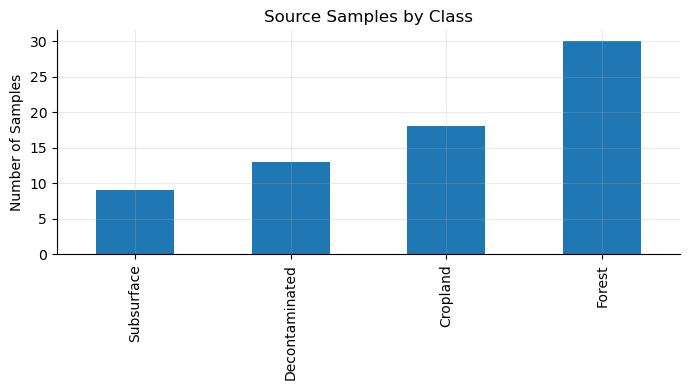

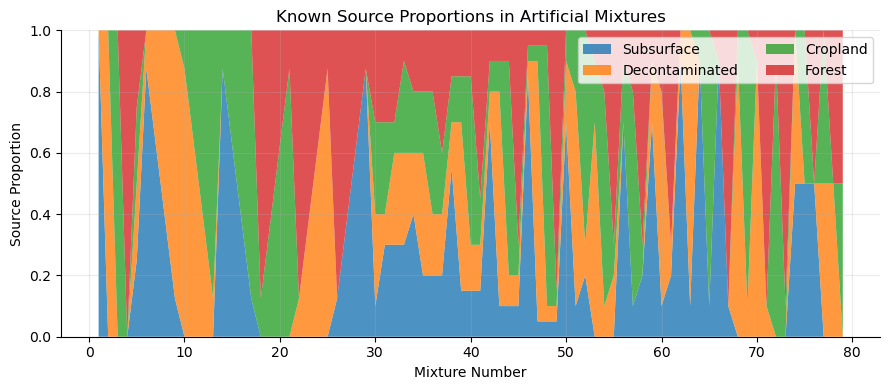

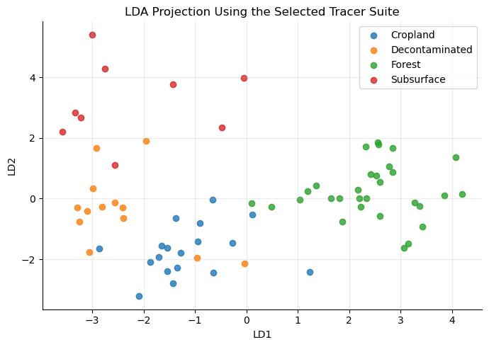

```
Cross-validated LDA accuracy: 0.871 ± 0.053
```

```python
# Source sample counts
fig, ax = plt.subplots(figsize=(7, 4))

sources["source_label"].value_counts().reindex(source_order).plot(
    kind="bar",
    ax=ax,
)

ax.set_title("Source Samples by Class")
ax.set_xlabel("")
ax.set_ylabel("Number of Samples")

fig.tight_layout()
fig.savefig(
    figures_dir / "source-counts.png",
    dpi=180,
    bbox_inches="tight",
    facecolor="white",
)

plt.show()


# Known source proportions
fig, ax = plt.subplots(figsize=(9, 4))

mixture_matrix = truth[source_order].to_numpy()

ax.stackplot(
    np.arange(1, len(truth) + 1),
    mixture_matrix.T,
    labels=source_order,
    alpha=0.8,
)

ax.set_title("Known Source Proportions in Artificial Mixtures")
ax.set_xlabel("Mixture Number")
ax.set_ylabel("Source Proportion")
ax.set_ylim(0, 1)
ax.legend(ncol=2, loc="upper right")

fig.tight_layout()
fig.savefig(
    figures_dir / "known-mixture-proportions.png",
    dpi=180,
    bbox_inches="tight",
    facecolor="white",
)

plt.show()


# LDA projection
x_scaled = StandardScaler().fit_transform(source_log_df[selected_tracers])
source_labels = source_log_df["source_label"].to_numpy()

lda = LinearDiscriminantAnalysis(n_components=2)
lda_scores = lda.fit_transform(x_scaled, source_labels)

lda_projection_df = pd.DataFrame({
    "LD1": lda_scores[:, 0],
    "LD2": lda_scores[:, 1],
    "source_label": source_labels,
})

fig, ax = plt.subplots(figsize=(7, 5))

for label, group in lda_projection_df.groupby("source_label"):
    ax.scatter(
        group["LD1"],
        group["LD2"],
        label=label,
        alpha=0.8,
    )

ax.set_title("LDA Projection Using the Selected Tracer Suite")
ax.set_xlabel("LD1")
ax.set_ylabel("LD2")
ax.legend()

fig.tight_layout()
fig.savefig(
    figures_dir / "lda-selected-tracers.png",
    dpi=180,
    bbox_inches="tight",
    facecolor="white",
)

plt.show()


# Cross-validated LDA performance
cv = StratifiedKFold(
    n_splits=5,
    shuffle=True,
    random_state=random_seed,
)

cv_scores = cross_val_score(
    LinearDiscriminantAnalysis(),
    x_scaled,
    source_labels,
    cv=cv,
)

print(
    f"Cross-validated LDA accuracy: "
    f"{cv_scores.mean():.3f} ± {cv_scores.std():.3f}"
)
```

## Methodology

Sediment source apportionment is formulated as a constrained mixing problem in which the contribution of each potential source must be non-negative and the estimated proportions must sum to one. Because fingerprint properties vary within each source group, the methodology adopts a stochastic framework that represents source variability and propagates uncertainty into the estimated source contributions.

Rather than assessing only point estimates, the predicted source contributions are treated as probability distributions and evaluated using interval coverage, interval width, residual-based metrics, the Continuous Ranked Probability Score (CRPS), the Nash–Sutcliffe Efficiency (NSE), and contingency metrics for identifying dominant sediment sources.

```python
def fit_simplex_least_squares(
    source_matrix: np.ndarray,
    target_vector: np.ndarray,
) -> np.ndarray:
    """
    Estimate source proportions by constrained least squares.

    Brief explanation:
    Solve the mixing equation under non-negativity and sum-to-one constraints.

    Inputs:
    source_matrix : np.ndarray
        Matrix with one source tracer vector per row.
    target_vector : np.ndarray
        Tracer vector for the mixture being apportioned.

    Outputs:
    np.ndarray
        Estimated source proportions on the simplex.

    Author:
    Rodrigo Kang
    """
    n_sources = source_matrix.shape[0]
    x0 = np.full(n_sources, 1 / n_sources)

    def objective(proportions: np.ndarray) -> float:
        residual = target_vector - proportions @ source_matrix
        return float(residual @ residual)

    constraints = {
        "type": "eq",
        "fun": lambda proportions: np.sum(proportions) - 1,
    }

    bounds = [(0.0, 1.0)] * n_sources

    result = minimize(
        objective,
        x0=x0,
        bounds=bounds,
        constraints=constraints,
        method="SLSQP",
    )

    if not result.success:
        clipped = np.clip(result.x, 0, 1)
        return clipped / clipped.sum()

    return result.x


def source_distribution_parameters(
    source_df: pd.DataFrame,
    tracers: list[str],
) -> dict[str, tuple[np.ndarray, np.ndarray]]:
    """
    Estimate source distributions in log-tracer space.

    Brief explanation:
    Compute the mean vector and covariance matrix for each sediment source class.

    Inputs:
    source_df : pd.DataFrame
        Source samples with source labels and selected tracers.
    tracers : list[str]
        Tracer columns used by the mixing model.

    Outputs:
    dict[str, tuple[np.ndarray, np.ndarray]]
        Mean vector and covariance matrix for each source class.

    Author:
    Rodrigo Kang
    """
    parameters = {}

    for label in source_order:
        values = source_df.loc[
            source_df["source_label"] == label,
            tracers,
        ].to_numpy()

        mean = values.mean(axis=0)
        covariance = np.cov(values, rowvar=False) + np.eye(len(tracers)) * 1e-6

        parameters[label] = (mean, covariance)

    return parameters


def draw_source_matrix(
    parameters: dict[str, tuple[np.ndarray, np.ndarray]],
    rng: np.random.Generator,
) -> np.ndarray:
    """
    Draw one stochastic source fingerprint matrix.

    Brief explanation:
    Sample one tracer vector from each source distribution for a Monte Carlo iteration.

    Inputs:
    parameters : dict[str, tuple[np.ndarray, np.ndarray]]
        Source-specific mean vectors and covariance matrices.
    rng : np.random.Generator
        Random number generator used for reproducible sampling.

    Outputs:
    np.ndarray
        Matrix containing one simulated tracer vector per source.

    Author:
    Rodrigo Kang
    """
    return np.vstack([
        rng.multivariate_normal(*parameters[label])
        for label in source_order
    ])


def bmm_apportion(
    source_df: pd.DataFrame,
    target_df: pd.DataFrame,
    truth_df: pd.DataFrame,
    tracers: list[str],
    mixture_type: str,
    iterations: int = bmm_iterations,
    rng: np.random.Generator | None = None,
) -> pd.DataFrame:
    """
    Run the bootstrapped mixing model.

    Brief explanation:
    Generate stochastic source and target tracer values, then estimate source proportions for each draw.

    Inputs:
    source_df : pd.DataFrame
        Log-transformed source tracer data.
    target_df : pd.DataFrame
        Log-transformed laboratory mixture tracer data.
    truth_df : pd.DataFrame
        Known source proportions for each artificial mixture.
    tracers : list[str]
        Selected tracer columns.
    mixture_type : str
        Either "Laboratory" or "Virtual".
    iterations : int
        Number of Monte Carlo iterations per mixture.
    rng : np.random.Generator | None
        Optional random generator for reproducibility.

    Outputs:
    pd.DataFrame
        Long-format table of stochastic source apportionment draws.

    Author:
    Rodrigo Kang
    """
    rng = np.random.default_rng(random_seed) if rng is None else rng

    parameters = source_distribution_parameters(source_df, tracers)
    target_lookup = target_df.set_index("sample")[tracers]
    truth_lookup = truth_df.set_index("sample")[source_order]

    records = []

    for sample in truth_df["sample"]:
        true_proportions = truth_lookup.loc[sample].to_numpy(float)
        measured_target = target_lookup.loc[sample].to_numpy(float)

        for draw_id in range(iterations):
            source_matrix = draw_source_matrix(parameters, rng)

            if mixture_type == "Laboratory":
                target_vector = rng.normal(measured_target, 0.05)
            elif mixture_type == "Virtual":
                target_vector = true_proportions @ source_matrix
            else:
                raise ValueError("mixture_type must be 'Laboratory' or 'Virtual'.")

            estimated_proportions = fit_simplex_least_squares(
                source_matrix=source_matrix,
                target_vector=target_vector,
            )

            for source_label, estimated_proportion in zip(
                source_order,
                estimated_proportions,
            ):
                records.append({
                    "sample": sample,
                    "mixture_type": mixture_type,
                    "model": "BMM",
                    "draw": draw_id,
                    "source_label": source_label,
                    "estimated_proportion": estimated_proportion,
                    "true_proportion": truth_lookup.loc[sample, source_label],
                })

    return pd.DataFrame.from_records(records)
```

## Model Development

The baseline implementation follows a bootstrapped mixing model (BMM). For each Monte Carlo draw, source fingerprints are sampled from source-specific multivariate distributions and source proportions are estimated through constrained least squares on the simplex.

A second Bayesian-style implementation is included to support model comparison. It uses an uninformative Dirichlet prior and a process-error likelihood, but it is presented as a transparent Python implementation rather than a full reconstruction of an external software workflow.

```python
def log_likelihood_mixture(
    proportions: np.ndarray,
    target: np.ndarray,
    source_means: np.ndarray,
    source_vars: np.ndarray,
    min_sd: float = 1e-3,
) -> float:
    """
    Evaluate the Gaussian process-error likelihood.

    Brief explanation:
    Score a candidate source proportion vector against a target mixture using source means and variances.

    Inputs:
    proportions : np.ndarray
        Candidate source proportion vector.
    target : np.ndarray
        Mixture tracer vector.
    source_means : np.ndarray
        Mean tracer values by source.
    source_vars : np.ndarray
        Tracer variances by source.
    min_sd : float
        Lower bound for standard deviations to avoid numerical instability.

    Outputs:
    float
        Log-likelihood value for the candidate source proportions.

    Author:
    Rodrigo Kang
    """
    expected = proportions @ source_means
    variance = (proportions**2) @ source_vars
    sd = np.sqrt(np.maximum(variance, min_sd**2))

    return float(
        np.sum(
            -0.5 * np.log(2 * np.pi * sd**2)
            - 0.5 * ((target - expected) / sd) ** 2
        )
    )


def bayesian_importance_apportion(
    source_df: pd.DataFrame,
    target_df: pd.DataFrame,
    truth_df: pd.DataFrame,
    tracers: list[str],
    mixture_type: str,
    candidates: int = bayesian_candidates,
    n_posterior_draws: int = posterior_draws,
    rng: np.random.Generator | None = None,
) -> pd.DataFrame:
    """
    Approximate Bayesian source apportionment with importance sampling.

    Brief explanation:
    Draw candidate source proportions from an uninformative Dirichlet prior and resample them by likelihood weight.

    Inputs:
    source_df : pd.DataFrame
        Log-transformed source tracer data.
    target_df : pd.DataFrame
        Log-transformed laboratory mixture tracer data.
    truth_df : pd.DataFrame
        Known source proportions for each artificial mixture.
    tracers : list[str]
        Selected tracer columns.
    mixture_type : str
        Either "Laboratory" or "Virtual".
    candidates : int
        Number of prior candidates.
    n_posterior_draws : int
        Number of posterior draws retained per mixture.
    rng : np.random.Generator | None
        Optional random generator for reproducibility.

    Outputs:
    pd.DataFrame
        Long-format table of posterior source apportionment draws.

    Author:
    Rodrigo Kang
    """
    rng = np.random.default_rng(random_seed) if rng is None else rng

    grouped_sources = source_df.groupby("source_label")[tracers]

    source_means = grouped_sources.mean().reindex(source_order).to_numpy()
    source_vars = grouped_sources.var(ddof=1).reindex(source_order).to_numpy() + 1e-6

    target_lookup = target_df.set_index("sample")[tracers]
    truth_lookup = truth_df.set_index("sample")[source_order]

    prior_proportions = rng.dirichlet(
        alpha=np.ones(len(source_order)),
        size=candidates,
    )

    records = []

    for sample in truth_df["sample"]:
        true_proportions = truth_lookup.loc[sample].to_numpy(float)

        if mixture_type == "Laboratory":
            target_vector = target_lookup.loc[sample].to_numpy(float)
        elif mixture_type == "Virtual":
            target_vector = true_proportions @ source_means
        else:
            raise ValueError("mixture_type must be 'Laboratory' or 'Virtual'.")

        log_weights = np.array([
            log_likelihood_mixture(
                proportions=proportions,
                target=target_vector,
                source_means=source_means,
                source_vars=source_vars,
            )
            for proportions in prior_proportions
        ])

        weights = np.exp(log_weights - logsumexp(log_weights))

        posterior_indices = rng.choice(
            np.arange(candidates),
            size=n_posterior_draws,
            replace=True,
            p=weights,
        )

        posterior_proportions = prior_proportions[posterior_indices]

        for draw_id, proportions in enumerate(posterior_proportions):
            for source_label, estimated_proportion in zip(source_order, proportions):
                records.append({
                    "sample": sample,
                    "mixture_type": mixture_type,
                    "model": "Bayesian",
                    "draw": draw_id,
                    "source_label": source_label,
                    "estimated_proportion": estimated_proportion,
                    "true_proportion": truth_lookup.loc[sample, source_label],
                })

    return pd.DataFrame.from_records(records)
```

## Training and Validation

This section runs the stochastic source apportionment models for all artificial mixtures. The bootstrapped mixing model (BMM) uses 2,500 Monte Carlo iterations to characterise uncertainty in the estimated source contributions.

For comparison, the notebook also evaluates a Bayesian importance-sampling implementation using the same source and mixture data. The results from both approaches are assessed with the evaluation framework described above.

```python
def crps_ensemble(samples: np.ndarray, observed: float) -> float:
    """
    Estimate the continuous ranked probability score from samples.

    Brief explanation:
    Compute CRPS for an empirical predictive distribution and a known observed proportion.

    Inputs:
    samples : np.ndarray
        Simulated source proportion draws.
    observed : float
        Known source proportion.

    Outputs:
    float
        Empirical CRPS value.

    Author:
    Rodrigo Kang
    """
    samples = np.asarray(samples, dtype=float)

    term_1 = np.mean(np.abs(samples - observed))

    sorted_samples = np.sort(samples)
    n_samples = len(sorted_samples)
    coefficients = 2 * np.arange(1, n_samples + 1) - n_samples - 1

    term_2 = np.sum(coefficients * sorted_samples) / (n_samples * n_samples)

    return float(term_1 - term_2)


def summarise_draws(draws: pd.DataFrame) -> pd.DataFrame:
    """
    Summarise stochastic apportionment draws.

    Brief explanation:
    Compute median and uncertainty intervals by model, mixture, sample and source.

    Inputs:
    draws : pd.DataFrame
        Long-format table of source apportionment draws.

    Outputs:
    pd.DataFrame
        Quantile summary merged with known source proportions.

    Author:
    Rodrigo Kang
    """
    quantile_summary = (
        draws
        .groupby(["model", "mixture_type", "sample", "source_label"])["estimated_proportion"]
        .quantile([0.025, 0.25, 0.5, 0.75, 0.975])
        .unstack()
        .reset_index()
        .rename(columns={
            0.025: "q025",
            0.25: "q25",
            0.5: "median",
            0.75: "q75",
            0.975: "q975",
        })
    )

    truth_columns = (
        draws[["sample", "source_label", "true_proportion"]]
        .drop_duplicates()
    )

    return quantile_summary.merge(
        truth_columns,
        on=["sample", "source_label"],
        how="left",
    )


def interval_error(row: pd.Series, lower: str, upper: str) -> float:
    """
    Compute signed interval error.

    Brief explanation:
    Return zero when the known value falls inside the interval; otherwise return the signed distance to the closest bound.

    Inputs:
    row : pd.Series
        Row containing the true proportion and interval bounds.
    lower : str
        Column name for the lower interval bound.
    upper : str
        Column name for the upper interval bound.

    Outputs:
    float
        Signed interval error.

    Author:
    Rodrigo Kang
    """
    observed = row["true_proportion"]

    if row[lower] <= observed <= row[upper]:
        return 0.0

    if observed < row[lower]:
        return float(row[lower] - observed)

    return float(row[upper] - observed)


def evaluate_draws(draws: pd.DataFrame) -> tuple[pd.DataFrame, pd.DataFrame]:
    """
    Evaluate stochastic source apportionment draws.

    Brief explanation:
    Compute interval, residual, CRPS, NSE and dominant-source contingency metrics.

    Inputs:
    draws : pd.DataFrame
        Long-format table of stochastic source apportionment draws.

    Outputs:
    tuple[pd.DataFrame, pd.DataFrame]
        Source-level summary table and model-level evaluation metrics.

    Author:
    Rodrigo Kang
    """
    summary = summarise_draws(draws)

    summary["p50_hit"] = (
        (summary["q25"] <= summary["true_proportion"])
        & (summary["true_proportion"] <= summary["q75"])
    )

    summary["p95_hit"] = (
        (summary["q025"] <= summary["true_proportion"])
        & (summary["true_proportion"] <= summary["q975"])
    )

    summary["w50"] = summary["q75"] - summary["q25"]
    summary["w95"] = summary["q975"] - summary["q025"]

    summary["e50"] = summary.apply(
        interval_error,
        axis=1,
        lower="q25",
        upper="q75",
    )

    summary["e95"] = summary.apply(
        interval_error,
        axis=1,
        lower="q025",
        upper="q975",
    )

    summary["ae50"] = summary["e50"].abs()
    summary["ae95"] = summary["e95"].abs()

    crps_records = []

    for keys, group in draws.groupby(["model", "mixture_type", "sample", "source_label"]):
        crps_records.append((
            *keys,
            crps_ensemble(
                samples=group["estimated_proportion"].to_numpy(),
                observed=group["true_proportion"].iloc[0],
            ),
        ))

    crps_df = pd.DataFrame(
        crps_records,
        columns=["model", "mixture_type", "sample", "source_label", "crps"],
    )

    summary = summary.merge(
        crps_df,
        on=["model", "mixture_type", "sample", "source_label"],
    )

    records = []

    for (model, mixture_type), group in summary.groupby(["model", "mixture_type"]):
        denominator = np.mean((group["true_proportion"] - 0.25) ** 2)

        record = {
            "model": model,
            "mixture_type": mixture_type,
            "p50": group["p50_hit"].mean(),
            "p95": group["p95_hit"].mean(),
            "w50": group["w50"].mean(),
            "w95": group["w95"].mean(),
            "mae50": group["ae50"].mean(),
            "mae95": group["ae95"].mean(),
            "me50": group["e50"].mean(),
            "me95": group["e95"].mean(),
            "crps": group["crps"].mean(),
            "nse50": 1 - np.mean(group["ae50"] ** 2) / denominator,
            "nse95": 1 - np.mean(group["ae95"] ** 2) / denominator,
        }

        contingency_records = []

        for _, sample_group in group.groupby("sample"):
            actual = set(
                sample_group.loc[
                    sample_group["true_proportion"] > 0.5,
                    "source_label",
                ]
            )

            predicted_50 = set(
                sample_group.loc[
                    sample_group["q75"] > 0.5,
                    "source_label",
                ]
            )

            predicted_95 = set(
                sample_group.loc[
                    sample_group["q975"] > 0.5,
                    "source_label",
                ]
            )

            for interval_name, predicted in [
                ("50", predicted_50),
                ("95", predicted_95),
            ]:
                contingency_records.append({
                    "interval": interval_name,
                    "hits": len(actual & predicted),
                    "misses": len(actual - predicted),
                    "false_alarms": len(predicted - actual),
                })

        contingency_df = pd.DataFrame(contingency_records)

        for interval_name in ["50", "95"]:
            interval_df = contingency_df.query("interval == @interval_name")

            hits = interval_df["hits"].sum()
            misses = interval_df["misses"].sum()
            false_alarms = interval_df["false_alarms"].sum()

            record[f"csi{interval_name}"] = (
                hits / (hits + misses + false_alarms)
                if (hits + misses + false_alarms)
                else np.nan
            )

            record[f"hr{interval_name}"] = (
                hits / (hits + misses)
                if (hits + misses)
                else np.nan
            )

        records.append(record)

    metrics = pd.DataFrame(records)

    return summary, metrics
```

```python
bmm_lab = bmm_apportion(
    source_log_df,
    target_log_df,
    truth,
    selected_tracers,
    "Laboratory",
    rng=np.random.default_rng(random_seed),
)

bmm_virtual = bmm_apportion(
    source_log_df,
    target_log_df,
    truth,
    selected_tracers,
    "Virtual",
    rng=np.random.default_rng(random_seed + 1),
)

bayes_lab = bayesian_importance_apportion(
    source_log_df,
    target_log_df,
    truth,
    selected_tracers,
    "Laboratory",
    rng=np.random.default_rng(random_seed + 2),
)

bayes_virtual = bayesian_importance_apportion(
    source_log_df,
    target_log_df,
    truth,
    selected_tracers,
    "Virtual",
    rng=np.random.default_rng(random_seed + 3),
)

all_draws = pd.concat(
    [
        bmm_lab,
        bmm_virtual,
        bayes_lab,
        bayes_virtual,
    ],
    ignore_index=True,
)

summary, metrics = evaluate_draws(all_draws)

summary.to_csv(
    tables_dir / "apportionment-summary.csv",
    index=False,
)

metrics.to_csv(
    tables_dir / "model-metrics.csv",
    index=False,
)

metrics.round(3)
```

|  | model | mixture_type | p50 | p95 | w50 | w95 | mae50 | mae95 | me50 | me95 | crps | nse50 | nse95 | csi50 | hr50 | csi95 | hr95 |
| --- | --- | --- | --- | --- | --- | --- | --- | --- | --- | --- | --- | --- | --- | --- | --- | --- | --- |
| 0 | BMM | Laboratory | 0.424 | 0.962 | 0.278 | 0.676 | 0.046 | 0.001 | -0.031 | -0.001 | 0.103 | 0.901 | 0.999 | 0.622 | 0.875 | 0.287 | 1.0 |
| 1 | BMM | Virtual | 0.978 | 1.000 | 0.000 | 0.001 | 0.000 | 0.000 | 0.000 | 0.000 | 0.000 | 1.000 | 1.000 | 0.842 | 1.000 | 0.842 | 1.0 |
| 2 | Bayesian | Laboratory | 0.253 | 0.528 | 0.168 | 0.450 | 0.072 | 0.012 | -0.013 | -0.006 | 0.102 | 0.873 | 0.990 | 0.757 | 0.875 | 0.398 | 1.0 |
| 3 | Bayesian | Virtual | 0.294 | 0.541 | 0.152 | 0.414 | 0.065 | 0.012 | -0.013 | -0.006 | 0.092 | 0.887 | 0.989 | 0.806 | 0.844 | 0.457 | 1.0 |

## Results and Evaluation

Model performance is assessed using metrics that consider both the accuracy and the uncertainty of the estimated source contributions. No single metric is sufficient to characterise model performance, so the results should be interpreted jointly.

Interval coverage (P50 and P95) and interval width (W50 and W95) describe the uncertainty associated with the source apportionments. Residual metrics (MAE and ME) quantify prediction errors, while the Continuous Ranked Probability Score (CRPS) evaluates both accuracy and sharpness of the predicted distributions. The modified Nash–Sutcliffe Efficiency (NSE) provides an overall measure of predictive skill, and the contingency metrics (CSI and Hit Rate) assess the ability of the models to correctly identify dominant sediment sources.

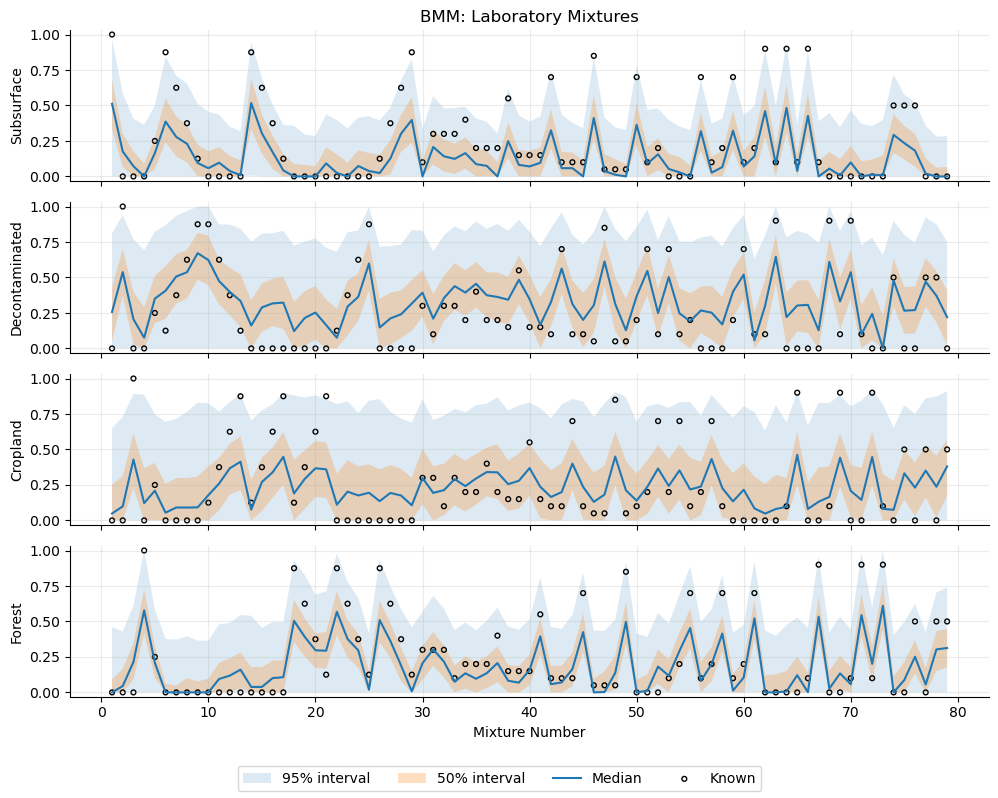

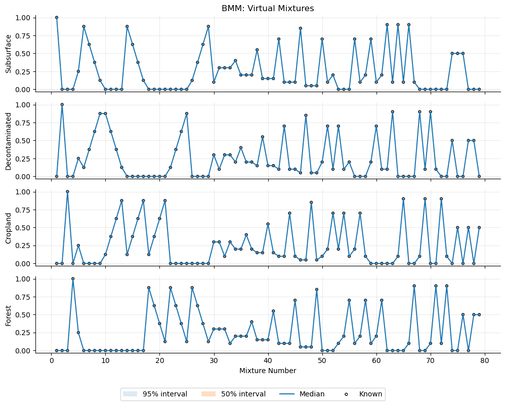

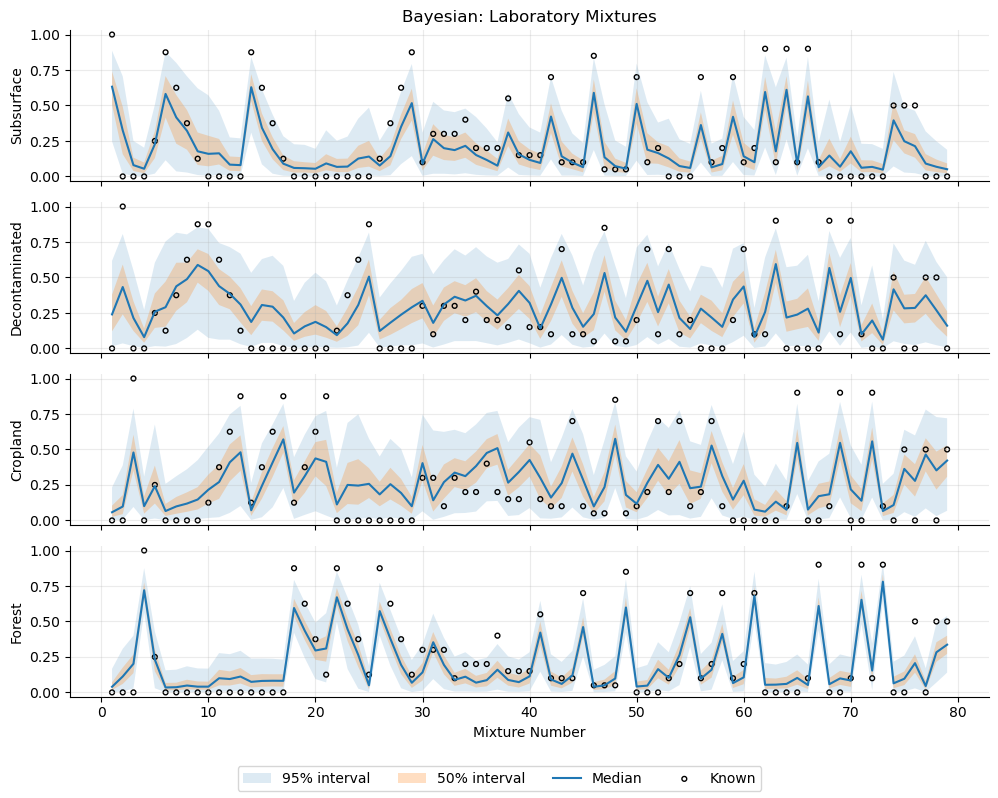

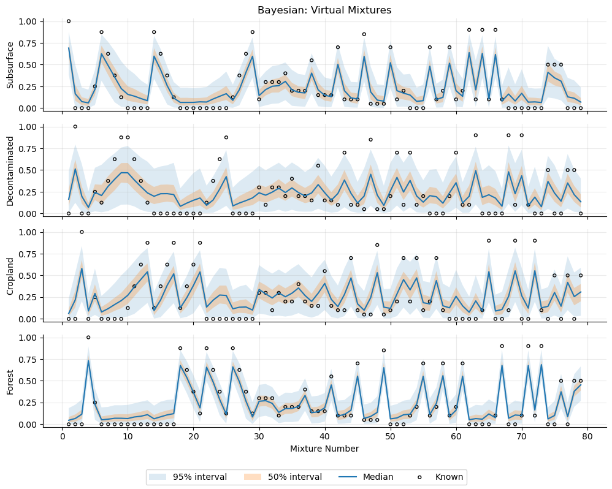

```python
def plot_model_intervals(
    summary_df: pd.DataFrame,
    model: str,
    mixture_type: str,
) -> None:
    """
    Plot predictive intervals for a source apportionment model.

    Brief explanation:
    Display the median estimated source contributions together with the 50% and
    95% predictive intervals and the known source proportions for each mixture.

    Inputs:
    summary_df : pd.DataFrame
        Quantile summary returned by evaluate_draws().
    model : str
        Source apportionment model to display.
    mixture_type : str
        Mixture dataset to display ("Laboratory" or "Virtual").

    Outputs:
    None
        Saves the figure to disk and displays it in the notebook.

    Author:
    Rodrigo Kang
    """
    data = summary_df.query(
        "model == @model and mixture_type == @mixture_type"
    ).copy()

    sample_order = {
        sample: index + 1
        for index, sample in enumerate(truth["sample"])
    }

    data["mixture_number"] = data["sample"].map(sample_order)

    fig, axes = plt.subplots(
        len(source_order),
        1,
        figsize=(10, 8),
        sharex=True,
        sharey=True,
    )

    for ax, source_label in zip(axes, source_order):
        subset = (
            data.query("source_label == @source_label")
            .sort_values("mixture_number")
        )

        x = subset["mixture_number"].to_numpy()

        ax.fill_between(x, subset["q025"], subset["q975"], alpha=0.15, label="95% interval")
        ax.fill_between(x, subset["q25"], subset["q75"], alpha=0.25, label="50% interval")
        ax.plot(x, subset["median"], linewidth=1.5, label="Median")

        ax.scatter(
            x,
            subset["true_proportion"],
            s=12,
            facecolors="none",
            edgecolors="black",
            label="Known",
        )

        ax.set_ylabel(source_label)
        ax.set_ylim(-0.03, 1.03)

    axes[-1].set_xlabel("Mixture Number")
    axes[0].set_title(f"{model}: {mixture_type} Mixtures")

    handles, labels = axes[0].get_legend_handles_labels()

    fig.legend(
        handles,
        labels,
        ncol=4,
        loc="lower center",
    )

    fig.tight_layout(rect=[0, 0.05, 1, 1])

    model_name = model.lower().replace(" ", "-")
    mixture_name = mixture_type.lower().replace(" ", "-")

    fig.savefig(
        figures_dir / f"{model_name}-{mixture_name}-intervals.png",
        dpi=180,
        bbox_inches="tight",
        facecolor="white",
    )

    plt.show()


plot_model_intervals(summary, "BMM", "Laboratory")
plot_model_intervals(summary, "BMM", "Virtual")

plot_model_intervals(summary, "Bayesian", "Laboratory")
plot_model_intervals(summary, "Bayesian", "Virtual")
```

```python
quantile_columns = ["q025", "q25", "median", "q75", "q975"]

comparison = summary.pivot_table(
    index=["model", "sample", "source_label"],
    columns="mixture_type",
    values=quantile_columns,
)

correlation_records = []

for model in summary["model"].unique():
    model_results = comparison.loc[model]

    for quantile in quantile_columns:
        correlation_records.append({
            "model": model,
            "quantile": quantile,
            "correlation": model_results[(quantile, "Laboratory")].corr(
                model_results[(quantile, "Virtual")]
            ),
        })

correlation_table = pd.DataFrame(correlation_records)

correlation_table.to_csv(
    tables_dir / "lab-vs-virtual-correlations.csv",
    index=False,
)

correlation_table.round(3)
```

|  | model | quantile | correlation |
| --- | --- | --- | --- |
| 0 | BMM | q025 | 0.173 |
| 1 | BMM | q25 | 0.862 |
| 2 | BMM | median | 0.810 |
| 3 | BMM | q75 | 0.747 |
| 4 | BMM | q975 | 0.571 |
| 5 | Bayesian | q025 | 0.921 |
| 6 | Bayesian | q25 | 0.925 |
| 7 | Bayesian | median | 0.929 |
| 8 | Bayesian | q75 | 0.931 |
| 9 | Bayesian | q975 | 0.933 |

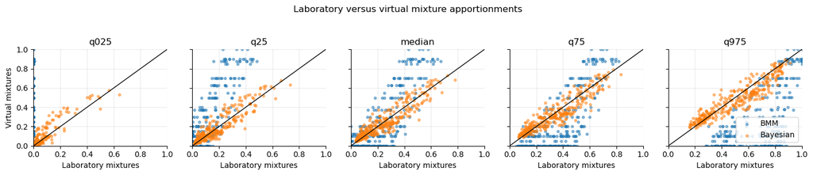

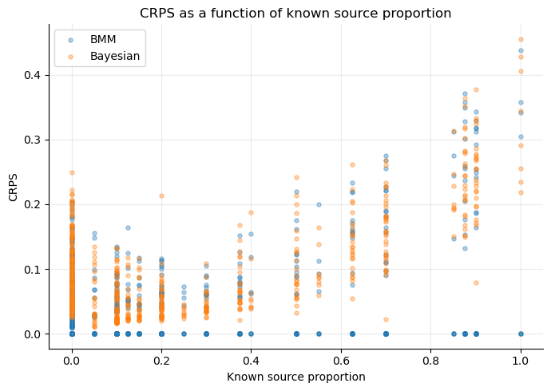

```python
fig, axes = plt.subplots(
    1,
    len(quantile_columns),
    figsize=(15, 3),
    sharex=True,
    sharey=True,
)

for ax, q in zip(axes, quantile_columns):
    for model in summary["model"].unique():
        sub = comparison.loc[model]

        ax.scatter(
            sub[(q, "Laboratory")],
            sub[(q, "Virtual")],
            s=10,
            alpha=0.5,
            label=model,
        )

    ax.plot([0, 1], [0, 1], color="black", linewidth=1)
    ax.set_title(q)
    ax.set_xlim(0, 1)
    ax.set_ylim(0, 1)
    ax.set_xlabel("Laboratory mixtures")

axes[0].set_ylabel("Virtual mixtures")
axes[-1].legend(loc="lower right")

fig.suptitle(
    "Laboratory versus virtual mixture apportionments",
    y=1.05,
)

fig.tight_layout()

fig.savefig(
    figures_dir / "lab-vs-virtual-quantiles.png",
    dpi=180,
    bbox_inches="tight",
    facecolor="white",
)

plt.show()


fig, ax = plt.subplots(figsize=(7, 5))

crps_col = "crps" if "crps" in summary.columns else "CRPS"

for model, group in summary.groupby("model"):
    ax.scatter(
        group["true_proportion"],
        group[crps_col],
        s=14,
        alpha=0.35,
        label=model,
    )

ax.set_title("CRPS as a function of known source proportion")
ax.set_xlabel("Known source proportion")
ax.set_ylabel("CRPS")
ax.legend()

fig.tight_layout()

fig.savefig(
    figures_dir / "crps-by-source-proportion.png",
    dpi=180,
    bbox_inches="tight",
    facecolor="white",
)

plt.show()
```

## Additional Diagnostics

The following diagnostics complement the main benchmark by exploring source separability, tracer-level differences, and the consistency of source apportionment estimates. They provide additional insight into model behavior without altering the primary evaluation framework.

```python
kruskal_records = []

for tracer in selected_tracers:
    samples_by_source = [
        source_log_df.loc[
            source_log_df["source_label"] == label,
            tracer,
        ].to_numpy()
        for label in source_order
    ]

    stat, p_value = kruskal(*samples_by_source)

    kruskal_records.append(
        {
            "tracer": tracer,
            "H_statistic": stat,
            "p_value": p_value,
        }
    )

kruskal_table = (
    pd.DataFrame(kruskal_records)
    .sort_values("p_value")
)

kruskal_table.to_csv(
    tables_dir / "kruskal-tracers.csv",
    index=False,
)

kruskal_table
```

|  | tracer | H_statistic | p_value |
| --- | --- | --- | --- |
| 0 | L | 51.647235 | 3.561117e-11 |
| 1 | h | 45.480099 | 7.315182e-10 |
| 2 | Si | 43.607076 | 1.828940e-09 |
| 8 | C_star | 34.421140 | 1.614378e-07 |
| 5 | K | 33.015397 | 3.196678e-07 |
| 7 | y | 23.563267 | 3.081335e-05 |
| 4 | Mn | 13.278328 | 4.071781e-03 |
| 3 | Zn | 12.499099 | 5.855116e-03 |
| 6 | Ti | 9.212896 | 2.659023e-02 |

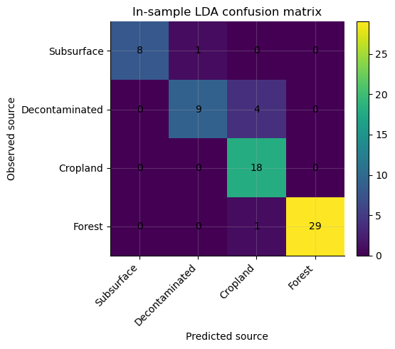

|  | model | mixture_type | source_label | mean_crps | median_abs_error | p95_coverage | w95 |
| --- | --- | --- | --- | --- | --- | --- | --- |
| 0 | BMM | Laboratory | Cropland | 0.115 | 0.118 | 0.962 | 0.801 |
| 1 | BMM | Laboratory | Decontaminated | 0.118 | 0.194 | 0.987 | 0.825 |
| 2 | BMM | Laboratory | Forest | 0.081 | 0.088 | 0.987 | 0.584 |
| 3 | BMM | Laboratory | Subsurface | 0.098 | 0.082 | 0.911 | 0.494 |
| 4 | BMM | Virtual | Cropland | 0.000 | 0.000 | 1.000 | 0.002 |
| 5 | BMM | Virtual | Decontaminated | 0.000 | 0.000 | 1.000 | 0.001 |
| 6 | BMM | Virtual | Forest | 0.000 | 0.000 | 1.000 | 0.001 |
| 7 | BMM | Virtual | Subsurface | 0.000 | 0.000 | 1.000 | 0.001 |
| 8 | Bayesian | Laboratory | Cropland | 0.114 | 0.137 | 0.557 | 0.523 |
| 9 | Bayesian | Laboratory | Decontaminated | 0.124 | 0.168 | 0.557 | 0.574 |
| 10 | Bayesian | Laboratory | Forest | 0.078 | 0.081 | 0.494 | 0.292 |
| 11 | Bayesian | Laboratory | Subsurface | 0.091 | 0.084 | 0.506 | 0.410 |
| 12 | Bayesian | Virtual | Cropland | 0.107 | 0.136 | 0.557 | 0.473 |
| 13 | Bayesian | Virtual | Decontaminated | 0.122 | 0.142 | 0.506 | 0.503 |
| 14 | Bayesian | Virtual | Forest | 0.059 | 0.066 | 0.557 | 0.298 |
| 15 | Bayesian | Virtual | Subsurface | 0.078 | 0.088 | 0.544 | 0.381 |

```python
lda_full = LinearDiscriminantAnalysis().fit(x_scaled, source_labels)
pred = lda_full.predict(x_scaled)

cm = pd.DataFrame(
    confusion_matrix(source_labels, pred, labels=source_order),
    index=source_order,
    columns=source_order,
)

cm.to_csv(
    tables_dir / "lda-confusion-matrix.csv",
)

fig, ax = plt.subplots(figsize=(6, 5))

im = ax.imshow(cm.to_numpy())

ax.set_xticks(
    np.arange(len(source_order)),
    labels=source_order,
    rotation=45,
    ha="right",
)

ax.set_yticks(
    np.arange(len(source_order)),
    labels=source_order,
)

for i, j in itertools.product(
    range(cm.shape[0]),
    range(cm.shape[1]),
):
    ax.text(
        j,
        i,
        cm.iloc[i, j],
        ha="center",
        va="center",
    )

ax.set_title("In-sample LDA confusion matrix")
ax.set_xlabel("Predicted source")
ax.set_ylabel("Observed source")

fig.colorbar(
    im,
    ax=ax,
    fraction=0.046,
    pad=0.04,
)

fig.tight_layout()

fig.savefig(
    figures_dir / "lda-confusion-matrix.png",
    dpi=180,
    bbox_inches="tight",
    facecolor="white",
)

plt.show()


source_level_metrics = (
    summary
    .assign(
        abs_median_error=lambda d: (
            d["median"] - d["true_proportion"]
        ).abs()
    )
    .groupby(
        ["model", "mixture_type", "source_label"]
    )
    .agg(
        mean_crps=("crps", "mean"),
        median_abs_error=("abs_median_error", "median"),
        p95_coverage=("p95_hit", "mean"),
        w95=("w95", "mean"),
    )
    .reset_index()
)

source_level_metrics.to_csv(
    tables_dir / "source-metrics.csv",
    index=False,
)

source_level_metrics.round(3)
```

## Final Remarks

This notebook implements the sediment fingerprinting evaluation workflow in Python, based on Batista et al. (2022). Rather than focusing on point estimates alone, it evaluates source apportionment as a probabilistic inference problem, emphasizing the accuracy, calibration, and uncertainty of the estimated source contributions.

The results highlight the complementary roles of laboratory and virtual mixtures. Laboratory mixtures provide the most reliable benchmark for validating source apportionment methods, while virtual mixtures enable broader sensitivity analyses when their underlying assumptions are appropriate. Assessing uncertainty intervals and dominant-source identification further strengthens the interpretation of model performance in practical applications.

The additional diagnostics presented here are intended to support model interpretation rather than introduce a new fingerprinting methodology. Together, they provide a more complete understanding of source discrimination, tracer behaviour, and uncertainty in sediment source apportionment.